# HW1: Association Rule Mining

#### let’s deal with outliers for each categorical variable on the basis of hrs/week worked

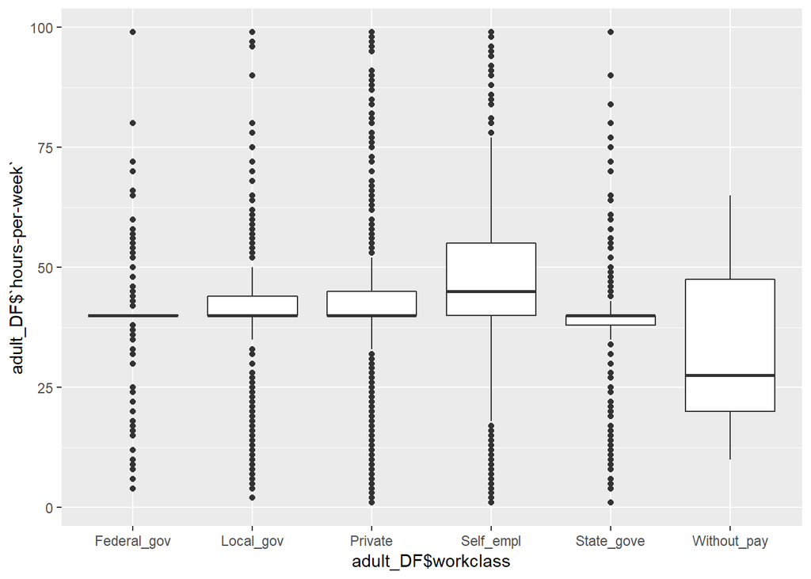

```r
ggplot(adult_DF, aes(x = adult_DF$workclass, y = adult_DF$`hours-per-week` )) +geom_boxplot()
```

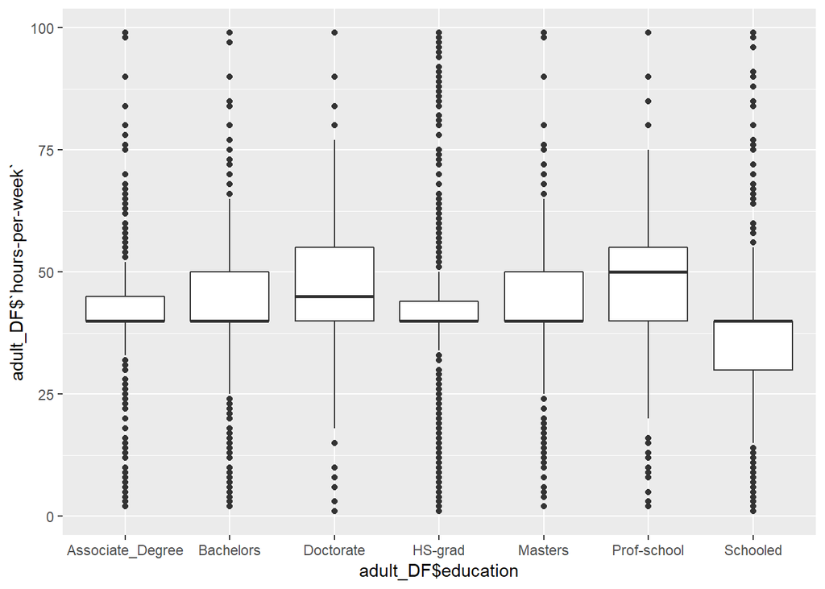

```r
ggplot(adult_DF, aes(x = adult_DF$education, y = adult_DF$`hours-per-week` )) +geom_boxplot()
```

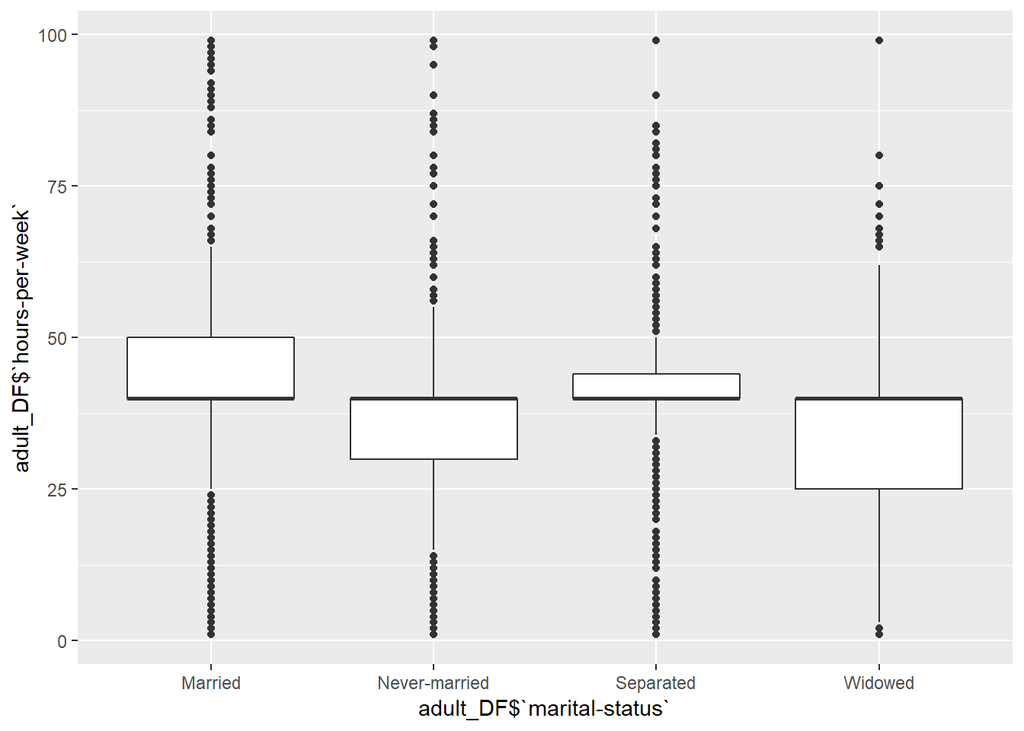

```r
ggplot(adult_DF, aes(x = adult_DF$`marital-status`, y = adult_DF$`hours-per-week` )) +geom_boxplot()
```

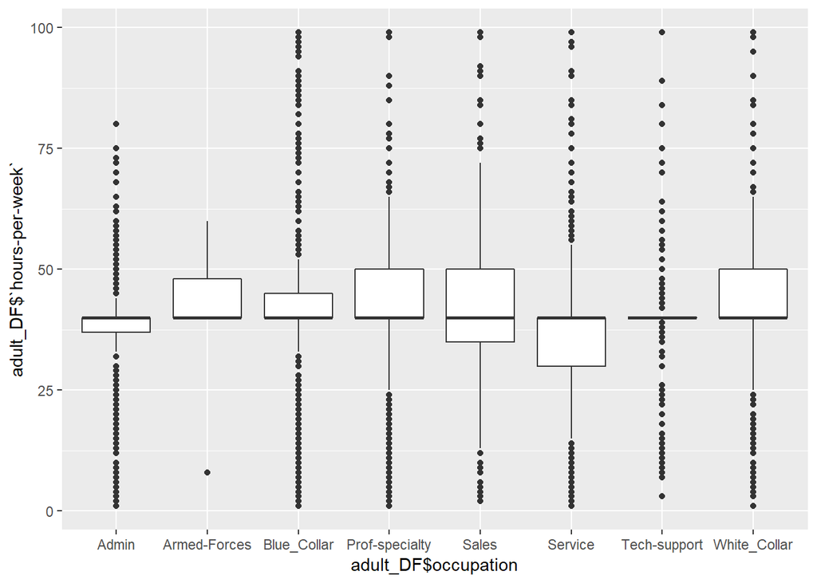

```r
ggplot(adult_DF, aes(x = adult_DF$occupation, y = adult_DF$`hours-per-week` )) +geom_boxplot()
```

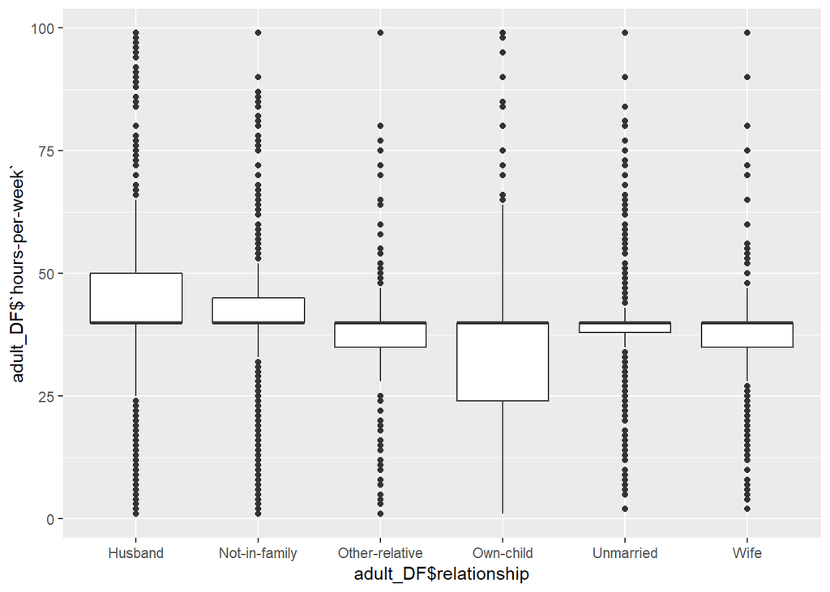

```r
ggplot(adult_DF, aes(x = adult_DF$relationship, y = adult_DF$`hours-per-week` )) +geom_boxplot()
```

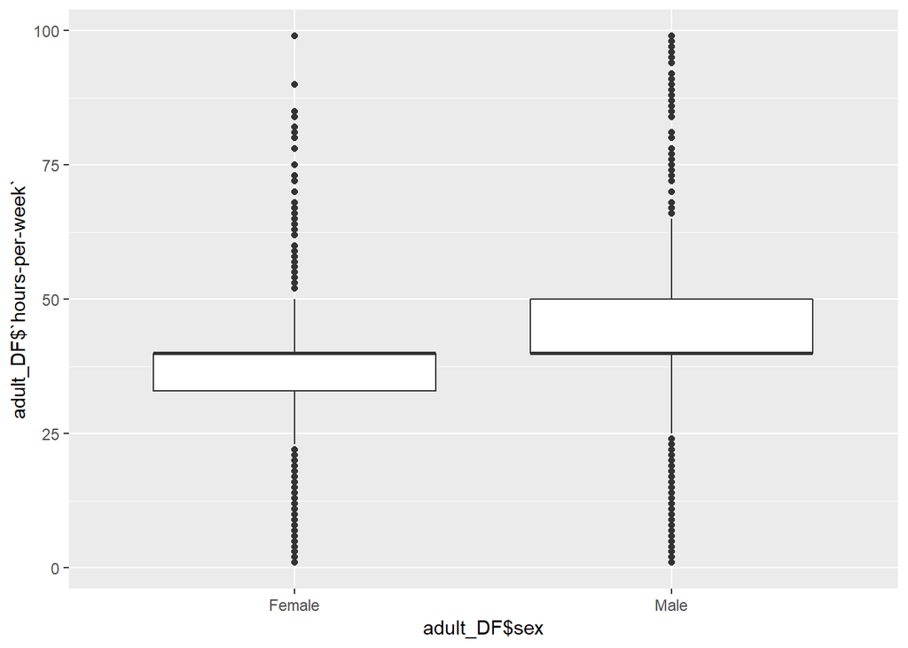

```r
ggplot(adult_DF, aes(x = adult_DF$sex, y = adult_DF$`hours-per-week` )) +geom_boxplot()
```

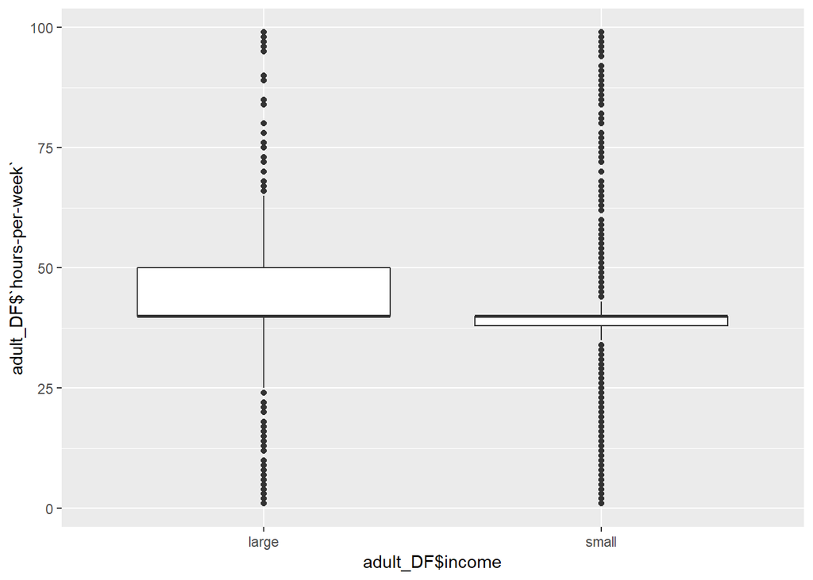

```r
ggplot(adult_DF, aes(x = adult_DF$income, y = adult_DF$`hours-per-week` )) +geom_boxplot()
```

#Data preprocessing, cleaning, transformation ####Normalising the data by detecting outliers in age using ‘lower fence-upper fence’ approach for skewed data

```r
summary(adult_DF$age)
```

```
##    Min. 1st Qu.  Median    Mean 3rd Qu.    Max.
##   17.00   28.00   37.00   38.44   47.00   90.00
```

```r
lf<- 28 - 1.5*(47-28) #lower fence , data obtained from summary
uf<- 47 + 1.5*(47-28) #upper fence , data obtained from summary
outliers_age<- nrow(adult_DF[(adult_DF$age< -0.5),])+nrow(adult_DF[(adult_DF$age> 75.5),])
outliers_age #Number of outliers in age
```

```
## [1] 169
```

```r
outlier_values <- boxplot.stats(adult_DF$age)$out
table(outlier_values)
```

```
## outlier_values
## 76 77 78 79 80 81 82 83 84 85 86 88 90
## 29 20 14 15 16 13  7  5  8  3  1  3 35
```

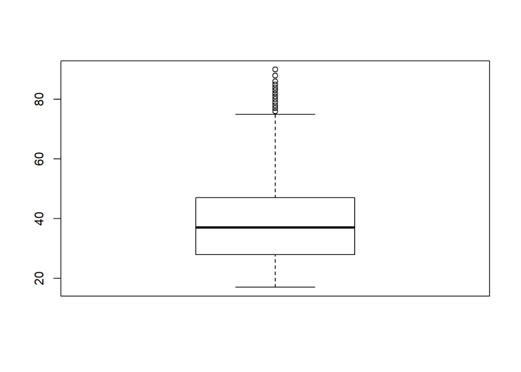

```r
boxplot(adult_DF$age)
```

####Removing noisy data by getting rid of outliers

```r
adult_DF$age[adult_DF$age %in% boxplot.stats(adult_DF$age)$out] <- median(adult_DF$age)

adult_DF$`hours-per-week`[adult_DF$`hours-per-week` %in% boxplot.stats(adult_DF$`hours-per-week`)$out] <- median(adult_DF$`hours-per-week`)
nrow(adult_DF)
```

```
## [1] 30162
```

```r
nrow(adult_DF[!duplicated(adult_DF), ])
```

```
## [1] 21660
```

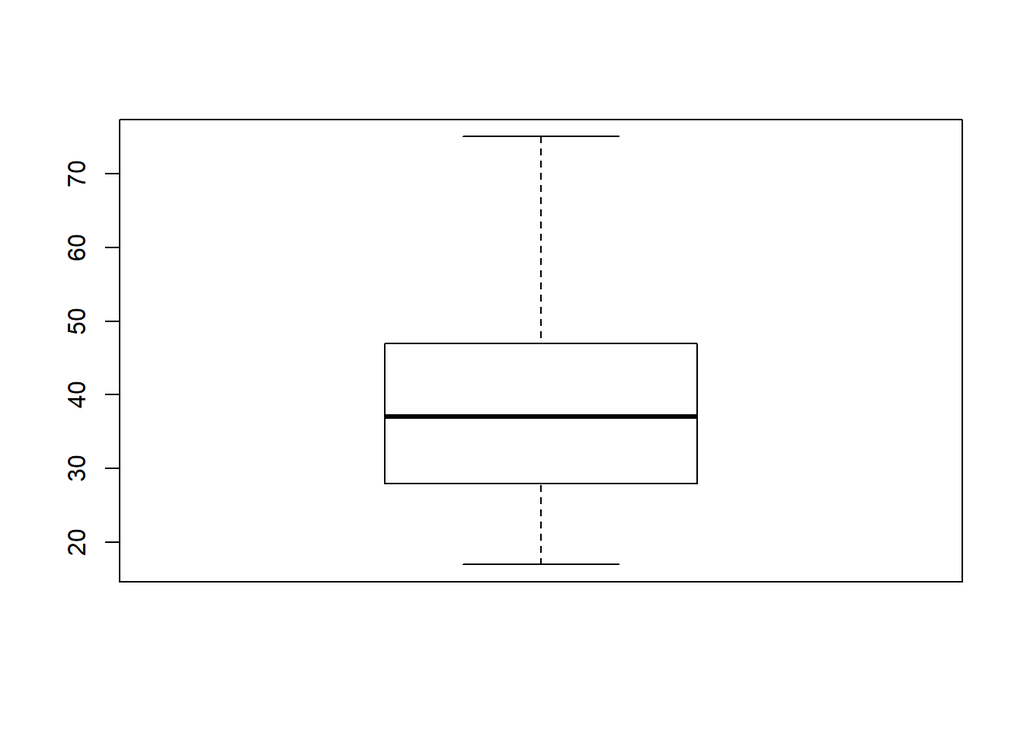

```r
boxplot(adult_DF$age)
```

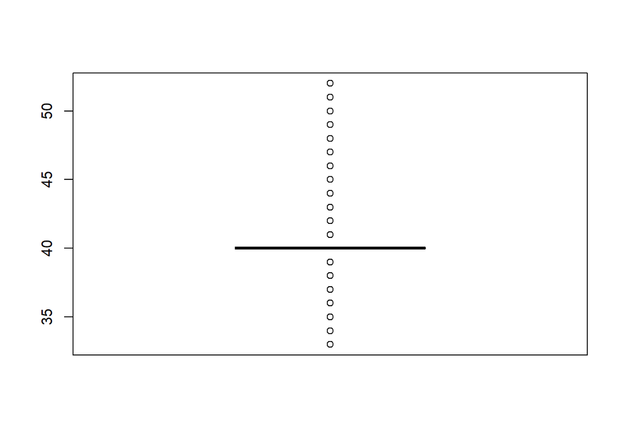

```r
boxplot(adult_DF$`hours-per-week`)
```

####Determining the ‘average hours/week’ on the basis of ‘sex’ and #‘marital status’

```r
hw_sex<- adult_DF %>% group_by(sex) %>% summarise(hwk=round(mean(`hours-per-week`))) %>% arrange(desc(hwk))
hw_sex
```

```
## # A tibble: 2 x 2
##   sex      hwk
##   <chr>  <dbl>
## 1 Male      42
## 2 Female    40
```

```r
hw_ms<- adult_DF %>% group_by(`marital-status`) %>% summarise(hwk2=round(mean(`hours-per-week`))) %>% arrange(desc(hwk2))
hw_ms
```

```
## # A tibble: 4 x 2
##   `marital-status`  hwk2
##   <chr>            <dbl>
## 1 Married             42
## 2 Never-married       41
## 3 Separated           41
## 4 Widowed             40
```

#### Running stratified data sampling to determine proportion of values in ‘marital status’

```r
round(prop.table(table(adult_DF$`marital-status`)),6)
```

```
##
##       Married Never-married     Separated       Widowed
##      0.467011      0.322459      0.183111      0.027419
```

#### we can observe that the value for widowed is negligible, we can just club separated and widowed

```r
adult_DF$`marital-status` = gsub('^Separated','Separated_Widowed',adult_DF$`marital-status`)
adult_DF$`marital-status` = gsub('^Widowed','Separated_Widowed',adult_DF$`marital-status`)
round(prop.table(table(adult_DF$`marital-status`)),6)
```

```
##
##           Married     Never-married Separated_Widowed
##          0.467011          0.322459          0.210530
```

```r
library(caret)
sample_index <- createDataPartition(adult_DF$`marital-status`, p = 0.3,list = F)
round(prop.table(table(adult_DF[sample_index, "marital-status"])),6)
```

```
##
##           Married     Never-married Separated_Widowed
##          0.467013          0.322467          0.210520
```

#### Discretizing the data from numerical discrete/continuous to categorical, as a-rules works on categorical datatypes

```r
library(dplyr)
save_adult_df<-adult_DF
adult_DF<-distinct(adult_DF)

table(adult_DF$`hours-per-week`)
```

```
##
##    33    34    35    36    37    38    39    40    41    42    43    44
##    37    27  1098   199   143   448    37 14361    33   208   141   201
##    45    46    47    48    49    50    51    52
##  1534    79    49   467    26  2305    13   132
```

```r
View(adult_DF)

adult_DF[[ "age"]] <- ordered(cut(adult_DF[[ "age"]], c(15,25,45,65,100)),labels = c("Young", "Middle-aged", "Senior", "Old"))

adult_DF[["hours-per-week"]] <- ordered(cut(adult_DF[["hours-per-week"]],c(20,36,46,60)),labels = c("Part-time","Full-time","Over-time"))



View(adult_DF)
adult_DF[[ "capital-gain"]] <- ordered(cut(adult_DF[[ "capital-gain"]],c(-Inf,0,median(adult_DF[[ "capital-gain"]][adult_DF[[ "capital-gain"]]>0]),Inf)), labels = c("None", "Low", "High"))

adult_DF[[ "capital-loss"]] <- ordered(cut(adult_DF[[ "capital-loss"]],c(-Inf,0, median(adult_DF[[ "capital-loss"]][adult_DF[[ "capital-loss"]]>0]),Inf)), labels = c("None", "Low", "High"))


table(adult_DF$`hours-per-week`)
```

```
##
## Part-time Full-time Over-time
##      1361     17185      2992
```

#### Converting dataset to factor datatype for a-rules mining

```r
adult_DF$age = as.factor(adult_DF$age)
adult_DF$workclass = as.factor(adult_DF$workclass)
adult_DF$education = as.factor(adult_DF$education)
adult_DF$`marital-status` = as.factor(adult_DF$`marital-status`)
adult_DF$occupation = as.factor(adult_DF$occupation)
adult_DF$relationship = as.factor(adult_DF$relationship)
adult_DF$race = as.factor(adult_DF$race)
adult_DF$sex = as.factor(adult_DF$sex)
adult_DF$`capital-gain` = as.factor(adult_DF$`capital-gain`)
adult_DF$`capital-loss` = as.factor(adult_DF$`capital-loss`)
adult_DF$`hours-per-week` = as.factor(adult_DF$`hours-per-week`)
adult_DF$`native-country` = as.factor(adult_DF$`native-country`)
adult_DF$income = as.factor(adult_DF$income)
str(adult_DF)
```

```
## 'data.frame':    21538 obs. of  13 variables:
##  $ age           : Ord.factor w/ 4 levels "Young"<"Middle-aged"<..: 2 3 2 3 2 2 3 3 2 2 ...
##  $ workclass     : Factor w/ 6 levels "Federal_gov",..: 5 4 3 3 3 3 3 4 3 3 ...
##  $ education     : Factor w/ 7 levels "Associate_Degree",..: 2 2 4 7 2 5 7 4 5 2 ...
##  $ marital-status: Factor w/ 3 levels "Married","Never-married",..: 2 1 3 1 1 1 3 1 2 1 ...
##  $ occupation    : Factor w/ 8 levels "Admin","Armed-Forces",..: 1 8 3 3 4 8 6 8 4 8 ...
##  $ relationship  : Factor w/ 6 levels "Husband","Not-in-family",..: 2 1 2 1 6 6 2 1 2 1 ...
##  $ race          : Factor w/ 5 levels "Amer-Indian-Eskimo",..: 5 5 5 3 3 5 3 5 5 5 ...
##  $ sex           : Factor w/ 2 levels "Female","Male": 2 2 2 2 1 1 1 2 1 2 ...
##  $ capital-gain  : Ord.factor w/ 3 levels "None"<"Low"<"High": 2 1 1 1 1 1 1 1 3 2 ...
##  $ capital-loss  : Ord.factor w/ 3 levels "None"<"Low"<"High": 1 1 1 1 1 1 1 1 1 1 ...
##  $ hours-per-week: Ord.factor w/ 3 levels "Part-time"<"Full-time"<..: 2 2 2 2 2 2 2 2 3 2 ...
##  $ native-country: Factor w/ 41 levels "Cambodia","Canada",..: 39 39 39 39 5 39 23 39 39 39 ...
##  $ income        : Factor w/ 2 levels "large","small": 2 2 2 2 2 2 2 1 1 1 ...
##  - attr(*, "na.action")= 'omit' Named int  15 28 39 52 62 70 78 94 107 129 ...
##   ..- attr(*, "names")= chr  "15" "28" "39" "52" ...
```

#### Run association rule mining algorithm using default settings

```r
default_asso_rules <- apriori(adult_DF)
```

```
## Apriori
##
## Parameter specification:
##  confidence minval smax arem  aval originalSupport maxtime support minlen
##         0.8    0.1    1 none FALSE            TRUE       5     0.1      1
##  maxlen target   ext
##      10  rules FALSE
##
## Algorithmic control:
##  filter tree heap memopt load sort verbose
##     0.1 TRUE TRUE  FALSE TRUE    2    TRUE
##
## Absolute minimum support count: 2153
##
## set item appearances ...[0 item(s)] done [0.00s].
## set transactions ...[93 item(s), 21538 transaction(s)] done [0.02s].
## sorting and recoding items ... [32 item(s)] done [0.00s].
## creating transaction tree ... done [0.02s].
## checking subsets of size 1 2 3 4 5 6 7 8 done [0.07s].
## writing ... [8678 rule(s)] done [0.00s].
## creating S4 object  ... done [0.00s].
```

```
## To reduce overplotting, jitter is added! Use jitter = 0 to prevent jitter.
```

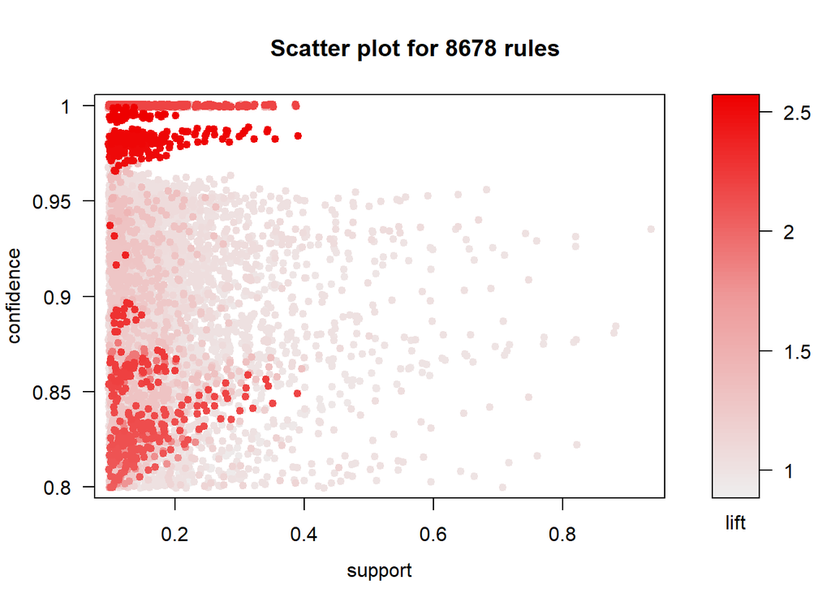

```r
plot(default_asso_rules, measure = c("support", "confidence"), shading = "lift")
```

```
## To reduce overplotting, jitter is added! Use jitter = 0 to prevent jitter.
```

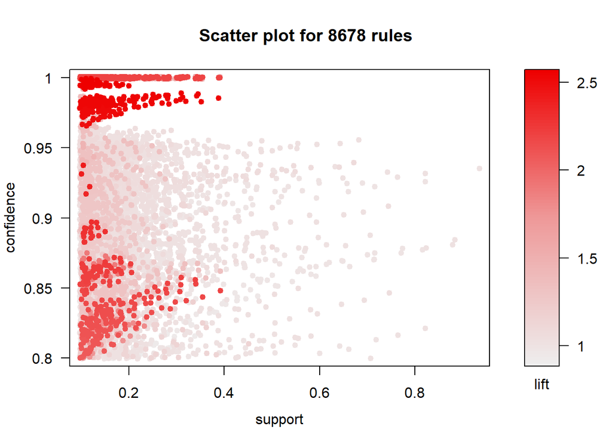

```r
plot(default_asso_rules, measure = c("support", "confidence"))
```

```r
inspect(head(sort(default_asso_rules, by = "lift", decreasing = T), 8))
```

```
##     lhs                               rhs                      support confidence     lift count
## [1] {age=Senior,
##      marital-status=Married,
##      sex=Male,
##      native-country=United-States} => {relationship=Husband} 0.1352958  0.9989715 2.564158  2914
## [2] {age=Senior,
##      marital-status=Married,
##      race=White,
##      sex=Male,
##      native-country=United-States} => {relationship=Husband} 0.1234098  0.9988726 2.563904  2658
## [3] {age=Senior,
##      marital-status=Married,
##      sex=Male,
##      capital-loss=None,
##      native-country=United-States} => {relationship=Husband} 0.1222026  0.9988615 2.563875  2632
## [4] {age=Senior,
##      marital-status=Married,
##      race=White,
##      sex=Male,
##      capital-loss=None,
##      native-country=United-States} => {relationship=Husband} 0.1110595  0.9987474 2.563583  2392
## [5] {age=Senior,
##      marital-status=Married,
##      sex=Male,
##      capital-gain=None,
##      native-country=United-States} => {relationship=Husband} 0.1094345  0.9987288 2.563535  2357
## [6] {age=Senior,
##      marital-status=Married,
##      sex=Male,
##      hours-per-week=Full-time,
##      native-country=United-States} => {relationship=Husband} 0.1045130  0.9986690 2.563381  2251
## [7] {age=Senior,
##      marital-status=Married,
##      race=White,
##      sex=Male,
##      capital-gain=None}            => {relationship=Husband} 0.1078559  0.9982810 2.562386  2323
## [8] {age=Senior,
##      marital-status=Married,
##      race=White,
##      sex=Male}                     => {relationship=Husband} 0.1333921  0.9982627 2.562338  2873
```

## Conclusion: If the population is Senior Married Male their relationship is Husband, couple of rules also state that these set of people generally do not involve in capital as its capital loss or gain is equal to None.

### Fine tune the model by experimenting with different algorithm parameters

```r
ruleset1<-apriori(data = adult_DF,parameter = list(supp=0.1,conf = 0.98, minlen =5))
```

```
## Apriori
##
## Parameter specification:
##  confidence minval smax arem  aval originalSupport maxtime support minlen
##        0.98    0.1    1 none FALSE            TRUE       5     0.1      5
##  maxlen target   ext
##      10  rules FALSE
##
## Algorithmic control:
##  filter tree heap memopt load sort verbose
##     0.1 TRUE TRUE  FALSE TRUE    2    TRUE
##
## Absolute minimum support count: 2153
##
## set item appearances ...[0 item(s)] done [0.00s].
## set transactions ...[93 item(s), 21538 transaction(s)] done [0.03s].
## sorting and recoding items ... [32 item(s)] done [0.00s].
## creating transaction tree ... done [0.02s].
## checking subsets of size 1 2 3 4 5 6 7 8 done [0.08s].
## writing ... [829 rule(s)] done [0.00s].
## creating S4 object  ... done [0.00s].
```

```
## To reduce overplotting, jitter is added! Use jitter = 0 to prevent jitter.
```

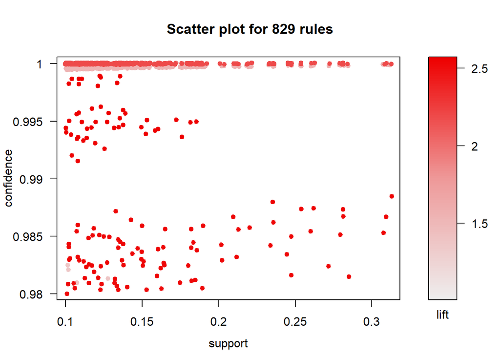

```r
#remove redundant rules
subset_rules1 <- which(colSums(is.subset(ruleset1, ruleset1)) > 1)
#sort rules
ruleset2<- sort(ruleset1[-subset_rules1], by = "lift", descreasing = T)
plot(ruleset1, measure = c("support", "confidence"), shading = "lift")
```

```r
inspect(head(ruleset2,5))
```

```
##     lhs                               rhs                        support confidence     lift count
## [1] {workclass=Private,
##      relationship=Husband,
##      race=White,
##      income=large}                 => {marital-status=Married} 0.1073452          1 2.177535  2312
## [2] {workclass=Private,
##      relationship=Husband,
##      native-country=United-States,
##      income=large}                 => {marital-status=Married} 0.1085523          1 2.177535  2338
## [3] {workclass=Private,
##      relationship=Husband,
##      capital-loss=None,
##      income=large}                 => {marital-status=Married} 0.1036772          1 2.177535  2233
## [4] {relationship=Husband,
##      race=White,
##      hours-per-week=Full-time,
##      income=large}                 => {marital-status=Married} 0.1354350          1 2.177535  2917
## [5] {relationship=Husband,
##      hours-per-week=Full-time,
##      native-country=United-States,
##      income=large}                 => {marital-status=Married} 0.1389173          1 2.177535  2992
```

## Conclusion:

Again we have married in rhs which states that if the working class is private and the person is from United States and is a Husband he is likely to be married.

### Output and present the most interesting and significant rules which could predict “income”

#### let’s take two cases since we have two categories in income, let’s carry out apriori for income small and income large

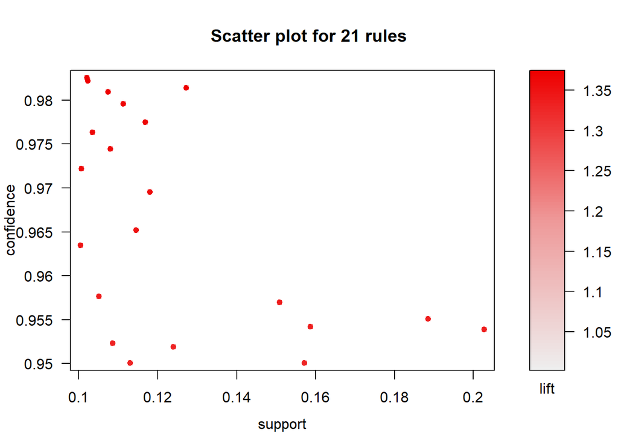

```r
small_income_rules <- apriori(data = adult_DF, parameter = list(supp = 0.1, conf = 0.95, minlen = 5),appearance = list(default = "lhs",rhs = c("income=small")),control = list(verbose = F))
#let's remove the redundant rules
subset_small_income_rules <- which(colSums(is.subset(small_income_rules, small_income_rules)) > 1)
#sort rules
sort_rules<- sort(small_income_rules[-subset_small_income_rules], by = "lift", descreasing = T)
plot(small_income_rules, measure = c("support", "confidence"), shading = "lift")
```

```r
inspect(head(sort_rules,5))
```

```
##     lhs                               rhs              support confidence     lift count
## [1] {workclass=Private,
##      education=HS-grad,
##      marital-status=Never-married,
##      capital-gain=None}            => {income=small} 0.1022843  0.9821667 1.372294  2203
## [2] {education=HS-grad,
##      marital-status=Never-married,
##      capital-gain=None,
##      capital-loss=None}            => {income=small} 0.1272634  0.9813820 1.371197  2741
## [3] {education=HS-grad,
##      marital-status=Never-married,
##      capital-gain=None,
##      hours-per-week=Full-time}     => {income=small} 0.1073916  0.9809160 1.370546  2313
## [4] {education=HS-grad,
##      marital-status=Never-married,
##      capital-gain=None,
##      native-country=United-States} => {income=small} 0.1168168  0.9774670 1.365727  2516
## [5] {workclass=Private,
##      education=HS-grad,
##      marital-status=Never-married,
##      capital-loss=None}            => {income=small} 0.1034451  0.9763365 1.364148  2228
```

## Conclusion:

A working class generally private, High school graduates, generally no capital class or gain and unmarried people generally have a very small income

# Let’s explore rules for income = large

```
## To reduce overplotting, jitter is added! Use jitter = 0 to prevent jitter.
```

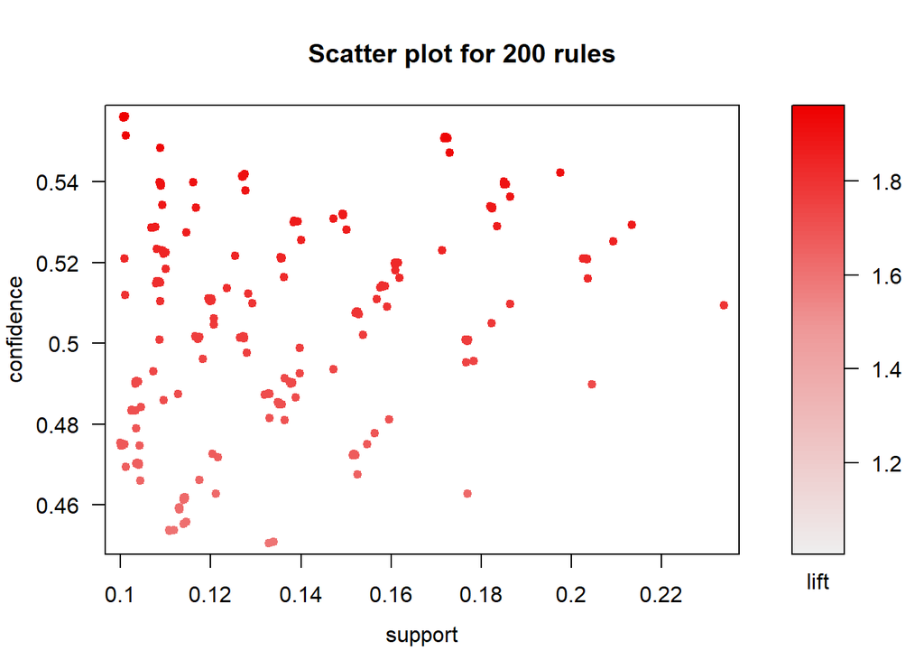

```r
large_income_rules <- apriori(data = adult_DF, parameter = list(supp = 0.1, conf = 0.45, minlen = 2),appearance = list(default = "lhs",rhs = c("income=large")),control = list(verbose = F))

#let's remove the redundant rules
subset_large_income_rules <- which(colSums(is.subset(large_income_rules, large_income_rules)) > 1)
#sort rules
sort_rules<- sort(large_income_rules[-subset_large_income_rules], by = "lift", descreasing = T)
plot(large_income_rules, measure = c("support", "confidence"), shading = "lift")
```

```r
inspect(head(large_income_rules,5))
```

```
##     lhs                         rhs              support confidence     lift count
## [1] {relationship=Husband}   => {income=large} 0.2029436  0.5209153 1.832349  4371
## [2] {marital-status=Married} => {income=large} 0.2340979  0.5097563 1.793097  5042
## [3] {marital-status=Married,
##      relationship=Husband}   => {income=large} 0.2029436  0.5209153 1.832349  4371
## [4] {age=Middle-aged,
##      relationship=Husband}   => {income=large} 0.1083666  0.5152318 1.812357  2334
## [5] {relationship=Husband,
##      sex=Male}               => {income=large} 0.2029436  0.5209774 1.832567  4371
```

## Conclusion:

Married,middle aged males are likely to be having a large income

### Shiny URL

http://127.0.0.1:4904/

OR

https://aangre-dataanalytics.shinyapps.io/SHINY_SUBMIT/